# Fisheries Conservation Features

### Fisheries Conservation Features

The following were used in this study:

1. Distribution of selected bycatch species
2. Distribution of larval spawning grounds of selected commercially targeted species

#### Bycatch Distribution

First, we compiled a list of bycatch reported in the Pacific ABNJ. Then, we extracted their **AquaMaps** distribution. AquaMaps (Kaschner et al., 2019) is a niche-based model that predicts the relative occurrences of species from their environmental envelopes or their environmental and oceanographic preferences (Kesner-Reyes et al., 2016).

We limited the bycatch included in this study to **sea turtles**, but this workflow can be easily replicated and expanded to include more species.

The relevant scripts for creating the bycatch distribution layer are labeled with a prefix of `02_RawAQM` and `03_AQM` in `~/scripts/`.

The plots below show the distribution of these species using a probability threshold of 0.5 and the functions `fAquaStart()` and `fBycatchDistMap()`.

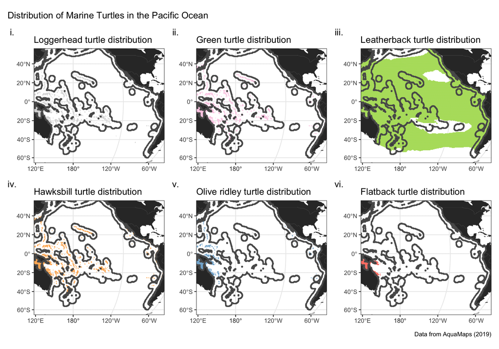

```r
# to extract the distribution of all species that are included in the AquaMaps dataset:
# the function is found in:
source("scripts/02a_RawAQM_fAquaStart.R")
# the function is ran in:
source("scripts/02b_RawAWM_fAquaStartRun.R")

# to create the distribution maps of the sea turtle species included in this study:
# the function is found in:
source("scripts/02c_RawAQM_fBycatchDistMap.R")
# the function is ran in:
source("scripts/02d_RawAQM_fBycatchDistMapRun.R")
```

#### Spawning grounds of Commercially Targeted Species

Just like the bycatch layer, we compiled a list of commercially targeted large pelagic species managed in the Pacific from different sources. From this list, we have 4 species with available data on their global larval spawning grounds:

- Yellowfin Tuna (*Thunnus albacares*)
- Albacore (*Thunnus alalunga*)
- Skipjack Tuna (*Katsuwonus pelamis*)
- Swordfish (*Xiphias gladius*)

The models for these species are from a report by Mercer (2019) where he created Generalized Additive Models (GAMs) to predict spawning grounds. He used average seasonal abundance from a historical dataset of longline fisheries surveys (dated back to the 1950s), and oceanographic and environmental conditions from global databases.

We reran his models (see scripts labeled with a prefix `05a` in `~/scripts/` for complete reruns) and used the medians of the predictions for each species as probability thresholds to create the distribution maps and the function `fCommercialFeat()`.

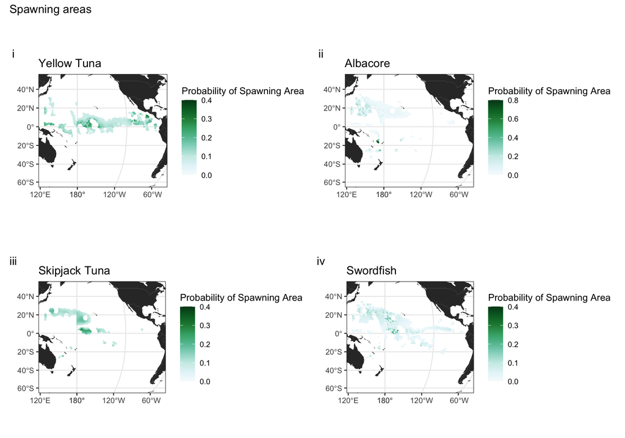

```r
# to intersect the results of the GAMs with the PUs
# the function is in:
source("scripts/05b_Commercial_fCommercialFeat.R")
# the function is ran at:
source("scripts/05c_Commercial_fCommercialFeatRun.R")
global_plots
```

#### Joining the conservation features’ layers with Longhurst provinces’ layer

We used the function `fProvIntersect()`.

```r
# to intersect the conservation features with the provinces
source("scripts/03_Features_fProvIntersect.R")

# function ran with the bycatch layer:
source("scripts/03b_AQM_fProvIntersectRun.R")
# function ran with the commercially targeted species layer:
source("scripts/05e_Commercial_fProvIntersect.R")
```

This is an example of how the data looks like (so far) for bycatch:

```r
head(bycatch)
```

```
## Simple feature collection with 6 features and 4 fields
## Geometry type: POLYGON
## Dimension:     XY
## Bounding box:  xmin: -3779074 ymin: 168708.9 xmax: -3695824 ymax: 473118.3
## CRS:           +proj=robin +lon_0=180 +x_0=0 +y_0=0 +ellps=WGS84 +datum=WGS84 +units=m +no_defs
## # A tibble: 6 x 5
## # Groups:   province [1]
##   province cellsID species                                 geometry new_feature
##   <chr>      <int> <chr>                              <POLYGON [m]> <chr>
## 1 WARM           1 ITS-Mam-… ((-3751324 216773.5, -3779074 232795.… WARM_ITS-Ma…
## 2 WARM           2 ITS-Mam-… ((-3751324 312902.8, -3779074 328924.… WARM_ITS-Ma…
## 3 WARM           3 ITS-Mam-… ((-3751324 409032.1, -3779074 425053.… WARM_ITS-Ma…
## 4 WARM           4 ITS-Mam-… ((-3723574 168708.9, -3751324 184730.… WARM_ITS-Ma…
## 5 WARM           5 ITS-Mam-… ((-3723574 264838.2, -3751324 280859.… WARM_ITS-Ma…
## 6 WARM           6 ITS-Mam-… ((-3723574 360967.5, -3751324 376989,… WARM_ITS-Ma…
```

And for the large pelagics:

```r
head(pelagic)
```

```
## Simple feature collection with 6 features and 4 fields
## Geometry type: POLYGON
## Dimension:     XY
## Bounding box:  xmin: -3779074 ymin: 216773.5 xmax: -3695824 ymax: 1482476
## CRS:           +proj=robin +lon_0=180 +x_0=0 +y_0=0 +ellps=WGS84 +datum=WGS84 +units=m +no_defs
## # A tibble: 6 x 5
## # Groups:   province [2]
##   province cellsID species                                  geometry new_feature
##   <chr>      <int> <chr>                               <POLYGON [m]> <chr>
## 1 WARM           1 ALB     ((-3751324 216773.5, -3779074 232795.1, … WARM_ALB
## 2 WARM           2 ALB     ((-3751324 312902.8, -3779074 328924.4, … WARM_ALB
## 3 WARM           3 ALB     ((-3751324 409032.1, -3779074 425053.6, … WARM_ALB
## 4 WARM           5 ALB     ((-3723574 264838.2, -3751324 280859.7, … WARM_ALB
## 5 WARM           6 ALB     ((-3723574 360967.5, -3751324 376989, -3… WARM_ALB
## 6 NPSW           7 ALB     ((-3723574 1418389, -3751324 1434411, -3… NPSW_ALB
```

Each `sf` object has the following columns:

- `province` is the longhurst province code
- `cellsID` is the unique ID for each hexagonal PU
- `species` is the species code (e.g. ALB = Albacore)
- `new_feature` is the subtyped features code (e.g. WARM-ALB = Albacore in the Western Pacific Warm Pool)
- `geometry`